# act_report

## Report: act_report

### Insights

#### 1. Tweet Correlation between Retweet and Favorite

I first found the correlation coefficient between the retweert_count and favorite_count variables.

The value: **0.91308377178509059.** This is very high and close to 1.0, which shows that there is a strong positive correlation between retweet_count and favorite_count variables.

#### 2. Which ones are the most adorable? Doggo, Puppo, Pupper or Floofer?

Since there is a positive correlation between retweet count and favorite count,I used the mean of the retweets for each 'nickname' to determine which ones are the most adorable

The dog classifications retweet_count mean was in the following order:

1. Puppo (7027)
2. Doggo (6868)
3. Floofer (4776)
4. Pupper (2405)

The mean values clearly indicate that **Puppors** are the most adorable among the 4 classifications with retweet_count mean of **7027**. The least adorable are the **Puppers** with a mean of **2405**.

#### 3. Which dog breed is the most popular

Since the column p1 has the most accurate values of the dog breed on the WeRateDogs Twitter, I used that to determine the most popular dog based on the mean of the retweet counts.

The breed **Zebra** is the most popular with a retweet count of **19213.5** and the breed **Acorn squash** is the least popular with a mean of **23**.

### Visualizations

#### 1. Tweet Correlation between Retweet and Favorite

I used a scatter plot to visually show the correlation between the retweet_count variable and the favorite_count variable

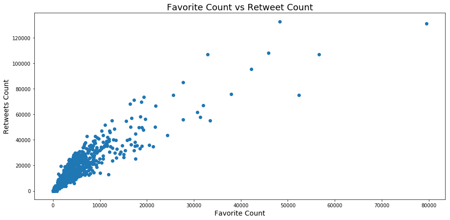